# UTS DECISION TREE: CLASSIFICATION LAB

…

April 2023, 2020

#Carseats {ISLR}

Sales of Child Car Seats Description A simulated data set containing sales of child car seats at 400 different stores. - Usage: Carseats - Format: A data frame with 400 observations on the following 11 variables. - Sales: Unit sales (in thousands) at each location - CompPrice: Price charged by competitor at each location - Income: Community income level (in thousands of dollars) - Advertising: Local advertising budget for company at each location (in thousands of dollars) - Population: Population size in region (in thousands) - Price: Price company charges for car seats at each site - ShelveLoc: A factor with levels Bad, Good and Medium indicating the quality of the shelving location for the car seats at each site - Age: Average age of the local population - Education: Education level at each location - Urban: A factor with levels No and Yes to indicate whether the store is in an urban or rural location - US: A factor with levels No and Yes to indicate whether the store is in the US or not - Source: Simulated data

References James, G., Witten, D., Hastie, T., and Tibshirani, R. (2013) An Introduction to Statistical Learning with applications in R, www.StatLearning.com, Springer-Verlag, New York

# Load libraries and data

```r
#Load tree library to construct classification trees
library("tree")

#Load library contains the Carseats data set.
library("ISLR")
#Load the Carseats data
attach(Carseats)
#View(Carseats)
head(Carseats, 5)
```

|  | Sales | CompPrice | Income | Advertising | Population | Price | ShelveLoc | Age | Education | Urban | US |
| --- | --- | --- | --- | --- | --- | --- | --- | --- | --- | --- | --- |
| 1 | 9.50 | 138 | 73 | 11 | 276 | 120 | Bad | 42 | 17 | Yes | Yes |
| 2 | 11.22 | 111 | 48 | 16 | 260 | 83 | Good | 65 | 10 | Yes | Yes |
| 3 | 10.06 | 113 | 35 | 10 | 269 | 80 | Medium | 59 | 12 | Yes | Yes |
| 4 | 7.40 | 117 | 100 | 4 | 466 | 97 | Medium | 55 | 14 | Yes | Yes |
| 5 | 4.15 | 141 | 64 | 3 | 340 | 128 | Bad | 38 | 13 | Yes | No |

# Create vector High that represent high sales and merge with original Carseats.

```r
library(dplyr)
rand1=6
rand2=9
threshold <- runif(1, rand1, rand2)
threshold
```

```
[1] 6.862733
```

```r
Carseats$Sales = sample(Carseats$Sales)
Carseats = Carseats %>%
  mutate(High = as.factor(ifelse(Sales <= threshold, "No", "Yes")))
head(Carseats)
```

|  | Sales | CompPrice | Income | Advertising | Population | Price | ShelveLoc | Age | Education | Urban | US | High |
| --- | --- | --- | --- | --- | --- | --- | --- | --- | --- | --- | --- | --- |
| 1 | 10.66 | 138 | 73 | 11 | 276 | 120 | Bad | 42 | 17 | Yes | Yes | Yes |
| 2 | 10.96 | 111 | 48 | 16 | 260 | 83 | Good | 65 | 10 | Yes | Yes | Yes |
| 3 | 7.23 | 113 | 35 | 10 | 269 | 80 | Medium | 59 | 12 | Yes | Yes | Yes |
| 4 | 8.03 | 117 | 100 | 4 | 466 | 97 | Medium | 55 | 14 | Yes | Yes | Yes |
| 5 | 8.80 | 141 | 64 | 3 | 340 | 128 | Bad | 38 | 13 | Yes | No | Yes |
| 6 | 10.98 | 124 | 113 | 13 | 501 | 72 | Bad | 78 | 16 | No | Yes | Yes |

```r
attach(Carseats)
```

# =========================================Descriptive

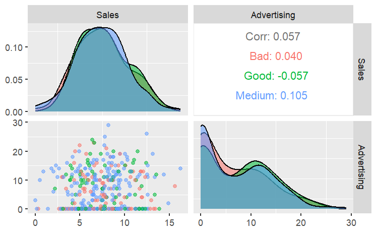

```r
library(dplyr)
Carseats %>%
  dplyr::mutate(ShelveLoc=as.factor(ShelveLoc)) %>%
  GGally::ggpairs(columns=c(1,4),
        mapping=ggplot2::aes(colour=ShelveLoc, alpha=0.5),
                diag=list(continuous="density",
                          discrete="bar"),
                upper=list(continuous="cor",
                           combo="box",
                           discrete="ratio"),
                lower=list(continuous="points",
                           combo="denstrip",
                           discrete="facetbar")) +
  ggplot2::theme(panel.grid.major=ggplot2::element_blank())
```

Gambar di atas memperlihatkan densitas dari Sales dan Advertising yang dikelompokkan menurut ShelveLoc # ==========================================

# Pertanyaan 1

Berikan pendapat Saudara tentang densitas Sales!

Jawaban: Pada kurva densitas Sales, diperlihatkan puncak dari ketiga indikator Bad, Good dan Medium saling berdekatan satu sama lain di sumbu y pada interval +- 0,15.Secara visual, indikator medium yang memiliki nilai tertinggi, ini menandakan bahwa rak dengan lokasi yang sedang, tidak terlalu bagus maupun buruk, memiliki penjualan yang tertinggi dibandingkan rak-rak dengan lokasi yang bagus maupun buruk. …

# ==========================================

# Pertanyaan 2

Berikan pendapat Saudara tentang densitas Advertising! Pada kurva densitas Advertising, Jawaban: Pada kurva densitas Advertising, diperlihatkan puncak dari ketiga indikator Bad, Good dan Medium saling berdekatan satu sama lain di sumbu x pada interval 0 sampai 2 dan terlihat memiliki lebih dari satu segmen, di mana segmen lainnya memiliki puncak di sumbu x pada interval 10 sampai 13. Secara visual, indikator medium yang memiliki nilai tertinggi, ini menandakan bahwa rak dengan lokasi yang sedang, tidak terlalu bagus maupun buruk, memiliki pengiklanan yang tertinggi dibandingkan rak-rak dengan lokasi yang bagus maupun buruk. …

# ==========================================

# Pertanyaan 3

Berikan pendapat Saudara tentang hubungan Sales dan Advertising!

# ==========================================

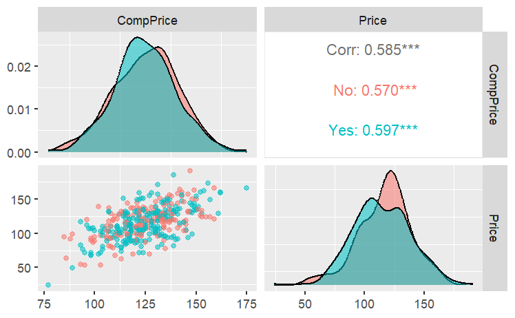

```r
Carseats %>%
  dplyr::mutate(High=as.factor(High)) %>%
  GGally::ggpairs(columns=c(2,6),
        mapping=ggplot2::aes(colour=High, alpha=0.5),
                diag=list(continuous="density",
                          discrete="bar"),
                upper=list(continuous="cor",
                           combo="box",
                           discrete="ratio"),
                lower=list(continuous="points",
                           combo="denstrip",
                           discrete="facetbar")) +
  ggplot2::theme(panel.grid.major=ggplot2::element_blank())
```

Gambar di atas memperlihatkan densitas dari CompPrice dan Price yang dikelompokkan menurut High.

#==========================================

#Pertanyaan 4 Berikan pendapat Saudara tentang hubungan Competitor Price dan (Own) Price!

Jawaban: Pada bagian korelasi, diperlihatkan bahwa Price dan CompPrice memiliki nilai korelasi positif sebesar 0,585, ini merupakan nilai korelasi yang cukup tinggi, yang menandakan bahwa jika Price meningkat, maka CompPrice juga akan meningkat dan begitu pun sebaliknya. …

#==========================================

# =========================================

#Predictive - Classification

Split dataset into train-test

```r
#Dataset for training
n = runif(1, 200, 300)
train=sample (1: nrow(Carseats ), n)  #Row sample for training data
head(train)
```

```
[1] 241  24 167  47 191  37
```

```r
#Dataset for testing
Carseats.test = Carseats [-train ,]
```

#Training Do the classification tree for Carseats using training data.

```r
set.seed(123)
tree.carseats = tree(High ~ .-Sales, Carseats, subset = train )

#Summarize the classification tree model
summary(tree.carseats)
```

```
Classification tree:
tree(formula = High ~ . - Sales, data = Carseats, subset = train)
Variables actually used in tree construction:
[1] "CompPrice"  "Population" "Urban"      "Price"      "Age"        "Income"     "Education"
[8] "ShelveLoc"
Number of terminal nodes:  30
Residual mean deviance:  0.7762 = 170 / 219
Misclassification error rate: 0.1807 = 45 / 249
```

#==========================================

#Pertanyaan 5 Berikan pendapat Saudara tentang summary dari model tree tersebut!

#==========================================

```r
#Text visualization of model
tree.carseats
```

```
node), split, n, deviance, yval, (yprob)
      * denotes terminal node

   1) root 249 345.000 Yes ( 0.4859 0.5141 )
     2) CompPrice < 110.5 41  52.640 No ( 0.6585 0.3415 )
       4) Population < 213 12  15.280 Yes ( 0.3333 0.6667 ) *
       5) Population > 213 29  29.570 No ( 0.7931 0.2069 )
        10) Urban: No 12   0.000 No ( 1.0000 0.0000 ) *
        11) Urban: Yes 17  22.070 No ( 0.6471 0.3529 )
          22) Population < 373.5 9   6.279 No ( 0.8889 0.1111 ) *
          23) Population > 373.5 8  10.590 Yes ( 0.3750 0.6250 ) *
     3) CompPrice > 110.5 208 286.400 Yes ( 0.4519 0.5481 )
       6) Price < 96.5 33  34.110 Yes ( 0.2121 0.7879 )
        12) Age < 48.5 13  17.940 Yes ( 0.4615 0.5385 )
          24) Price < 88 5   5.004 No ( 0.8000 0.2000 ) *
          25) Price > 88 8   8.997 Yes ( 0.2500 0.7500 ) *
        13) Age > 48.5 20   7.941 Yes ( 0.0500 0.9500 ) *
       7) Price > 96.5 175 242.600 Yes ( 0.4971 0.5029 )
        14) Population < 487 164 227.000 Yes ( 0.4756 0.5244 )
          28) Income < 91.5 127 173.800 Yes ( 0.4331 0.5669 )
            56) Education < 11.5 32  43.230 No ( 0.5938 0.4062 )
             112) CompPrice < 138.5 26  36.040 No ( 0.5000 0.5000 )
               224) Income < 83.5 21  27.910 Yes ( 0.3810 0.6190 )
                 448) Urban: No 5   0.000 Yes ( 0.0000 1.0000 ) *
                 449) Urban: Yes 16  22.180 Yes ( 0.5000 0.5000 )
                   898) CompPrice < 124.5 10  12.220 No ( 0.7000 0.3000 ) *
                   899) CompPrice > 124.5 6   5.407 Yes ( 0.1667 0.8333 ) *
               225) Income > 83.5 5   0.000 No ( 1.0000 0.0000 ) *
             113) CompPrice > 138.5 6   0.000 No ( 1.0000 0.0000 ) *
            57) Education > 11.5 95 126.100 Yes ( 0.3789 0.6211 )
             114) Age < 74 86 116.900 Yes ( 0.4186 0.5814 )
               228) Education < 15.5 49  60.360 Yes ( 0.3061 0.6939 )
                 456) Age < 66.5 42  46.110 Yes ( 0.2381 0.7619 )
                   912) Age < 62 34  41.190 Yes ( 0.2941 0.7059 )
                    1824) Income < 79 28  29.100 Yes ( 0.2143 0.7857 )
                      3648) Price < 133 20  24.430 Yes ( 0.3000 0.7000 )
                        7296) Price < 115 6   0.000 Yes ( 0.0000 1.0000 ) *
                        7297) Price > 115 14  19.120 Yes ( 0.4286 0.5714 ) *
                      3649) Price > 133 8   0.000 Yes ( 0.0000 1.0000 ) *
                    1825) Income > 79 6   7.638 No ( 0.6667 0.3333 ) *
                   913) Age > 62 8   0.000 Yes ( 0.0000 1.0000 ) *
                 457) Age > 66.5 7   8.376 No ( 0.7143 0.2857 ) *
               229) Education > 15.5 37  50.620 No ( 0.5676 0.4324 )
                 458) Income < 81.5 32  41.180 No ( 0.6562 0.3438 )
                   916) Age < 60.5 27  36.500 No ( 0.5926 0.4074 )
                    1832) CompPrice < 132 13  17.320 Yes ( 0.3846 0.6154 ) *
                    1833) CompPrice > 132 14  14.550 No ( 0.7857 0.2143 )
                      3666) Income < 45.5 5   6.730 Yes ( 0.4000 0.6000 ) *
                      3667) Income > 45.5 9   0.000 No ( 1.0000 0.0000 ) *
                   917) Age > 60.5 5   0.000 No ( 1.0000 0.0000 ) *
                 459) Income > 81.5 5   0.000 Yes ( 0.0000 1.0000 ) *
             115) Age > 74 9   0.000 Yes ( 0.0000 1.0000 ) *
          29) Income > 91.5 37  49.080 No ( 0.6216 0.3784 )
            58) Income < 110.5 26  30.290 No ( 0.7308 0.2692 )
             116) Income < 104 18  24.060 No ( 0.6111 0.3889 )
               232) ShelveLoc: Bad 5   0.000 No ( 1.0000 0.0000 ) *
               233) ShelveLoc: Good,Medium 13  17.940 Yes ( 0.4615 0.5385 ) *
             117) Income > 104 8   0.000 No ( 1.0000 0.0000 ) *
            59) Income > 110.5 11  14.420 Yes ( 0.3636 0.6364 ) *
        15) Population > 487 11  10.430 No ( 0.8182 0.1818 )
          30) Income < 62 6   0.000 No ( 1.0000 0.0000 ) *
          31) Income > 62 5   6.730 No ( 0.6000 0.4000 ) *
```

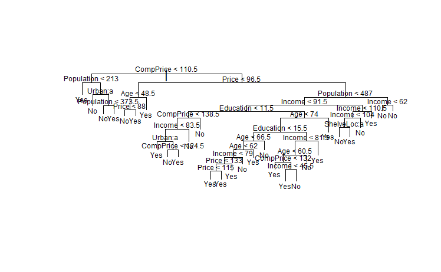

```r
#Tree visualization of model
plot(tree.carseats )
text(tree.carseats ,cex=1/2)
```

#==========================================

# Pertanyaan 6

Pilih cabang yang menarik bagi Saudara dan jelaskan! Mahasiswa boleh memilih cabang mana saja asal menjelaskan alasannya. Dalam realitas ini menggambarkan proses pengambilan keputusan dan alasan yang mendasarinya.

#==========================================

#Evaluate the decision tree model using test data.

```r
#Predict the model using data testing Carseats.test
set.seed(123)
tree.pred=predict(tree.carseats , Carseats.test, type ="class")
head(tree.pred, 5)
```

```
[1] No  Yes Yes No  No
Levels: No Yes
```

```r
#Generate the confusion matrix showing proportions from testing data .
print("confusion matrix showing test proportion")
```

```
[1] "confusion matrix showing test proportion"
```

```r
per <- rattle::errorMatrix(Carseats.test$High, tree.pred, count = FALSE)
per
```

```
      Predicted
Actual   No  Yes Error
   No  12.6 21.2  62.7
   Yes 19.2 47.0  29.0
```

```r
#Calculate the testing overall error percentage.
print("overall error percentage")
```

```
[1] "overall error percentage"
```

```r
cat(100-sum(diag(per), na.rm=TRUE))
```

```
40.4
```

#==========================================

# Pertanyaan 7

Sebagai pengambil keputusan, berikan jugdement Saudara berkaitan dengan target perusahaan mengenai nilai True Positive yang didapatkan dari hasil pengujian model menggunakan data testing! Bandingkan dengan model training di atas (kaitkan dengan jawaban pertanyaan no 6 di atas).

#==========================================

Calculate the testing overall error percentage.

```r
print("overall error percentage")
```

```
[1] "overall error percentage"
```

```r
cat(100-sum(diag(per), na.rm=TRUE))
```

```
40.4
```

#==========================================

# Pertanyaan 8

Menggunakan kriteria hasil testing (“overall error percentage”), sebagai pengambil keputusan, berikan jugdement Saudara berkaitan dengan target perusahaan mengenai nilai True overall accuracy! Berapa kira2 asumsi yang acceptable menurut Saudara?

Jawaban: Nilai overall error percentage yang didapat dari hasil simulasi sebesar 40,4%. Menurut saya, persentase ini masihlah cukup besar, karena dengan 40,4% overall error percentage, maka akurasi yang dimiliki oleh pohon yang digunakan hanya 59,6%. Nilai ini jauh lebih rendah jika dibandingkan dengan penelitian yang dilakukan oleh Jijo & Abdulazeez (2021) yang memiliki akurasi sebesar 99,93% dengan menggunakan dataset dari repository machine learning. …

#==========================================

#==========================================

# Pertanyaan 9

Berdasarkan analisis pruning atas model training di bawah ini, apakah Saudara akan melakukan pruning? Jelaskan alasan Saudara!

(Catatan, pruning atas model decision tree dilakukan apabila memberikan keuntungan dari sisi “Number of terminal nodes” dan “overall accuracy”)

#==========================================

#Pruning the tree Berikut adalah langkah-langkah analisis pruning

1. Gunakan kriteria cross validation untuk melakukan pruning

```r
#Calculate deviance
set.seed (123)
cv.carseats = cv.tree(tree.carseats, FUN=prune.misclass, K = 10)
cv.carseats
```

```
$size
 [1] 30 27 25 20 16 14 12 10  7  6  2  1

$dev
 [1] 127 127 125 125 126 134 134 136 132 131 132 131

$k
 [1]      -Inf  0.000000  0.500000  1.000000  1.500000  2.000000  2.500000  3.000000  3.333333
[10]  4.000000  5.500000 13.000000

$method
[1] "misclass"

attr(,"class")
[1] "prune"         "tree.sequence"
```

[figure not shown]

```r
#We plot the error rate as a function of both size and k.
par(mfrow=c(1,2))
plot(cv.carseats$size ,cv.carseats$dev ,type="b")
plot(cv.carseats$k ,cv.carseats$dev ,type="b")
```

2. Menggunakan grafik tersebut di atas, tetapkan best sizenya lalu lakukan pruning dan visualisasikan. Apakah ada perbaikan jumlah daun dibandingkan dengan model sebelum pruning.

```r
#Prune the best size
set.seed(123)
best_size = 5
prune.carseats = prune.misclass(tree.carseats , best = best_size)

#Summary of pruning result
summary(prune.carseats)
```

```
Classification tree:
snip.tree(tree = tree.carseats, nodes = c(15L, 6L, 56L, 29L,
57L, 2L))
Variables actually used in tree construction:
[1] "CompPrice"  "Price"      "Population" "Income"     "Education"
Number of terminal nodes:  6
Residual mean deviance:  1.299 = 315.6 / 243
Misclassification error rate: 0.3454 = 86 / 249
```

```r
#Text visualization
prune.carseats
```

```
node), split, n, deviance, yval, (yprob)
      * denotes terminal node

 1) root 249 345.00 Yes ( 0.4859 0.5141 )
   2) CompPrice < 110.5 41  52.64 No ( 0.6585 0.3415 ) *
   3) CompPrice > 110.5 208 286.40 Yes ( 0.4519 0.5481 )
     6) Price < 96.5 33  34.11 Yes ( 0.2121 0.7879 ) *
     7) Price > 96.5 175 242.60 Yes ( 0.4971 0.5029 )
      14) Population < 487 164 227.00 Yes ( 0.4756 0.5244 )
        28) Income < 91.5 127 173.80 Yes ( 0.4331 0.5669 )
          56) Education < 11.5 32  43.23 No ( 0.5938 0.4062 ) *
          57) Education > 11.5 95 126.10 Yes ( 0.3789 0.6211 ) *
        29) Income > 91.5 37  49.08 No ( 0.6216 0.3784 ) *
      15) Population > 487 11  10.43 No ( 0.8182 0.1818 ) *
```

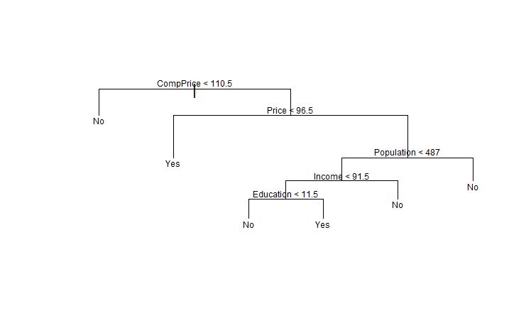

```r
#Tree visualization
plot(prune.carseats )
text(prune.carseats ,col=1, cex=1/2)
```

3. Ujikan hasil model pruning menggunakan test data set.

```r
#Predict using pruned tree model
set.seed(123)
tree_pred = predict(prune.carseats, Carseats.test, type="class")

#Generate the confusion matrix showing counts for pruned tree.
print("confusion matrix showing test counts")
```

```
[1] "confusion matrix showing test counts"
```

```r
per_pruned <- rattle::errorMatrix(Carseats.test$High, tree_pred, count=FALSE)
per_pruned
```

```
      Predicted
Actual   No  Yes Error
   No  16.6 17.2    51
   Yes 31.8 34.4    48
```

```r
#Overall error
print("overall error percentage")
```

```
[1] "overall error percentage"
```

```r
cat(100-sum(diag(per_pruned), na.rm=TRUE))
```

```
49
```

# Prediksi

#==========================================

# Pertanyaan 10

Toko dengan kondisi sebagai berikut: “CompPrice=115”, “Income=28”, “Advertising=11”, “Population=29”, “Price=86”, “ShelveLoc=Good”, “Age=53”, “Education=18”, “Urban=Yes”, “US=Yes”.

Lakukan prediksi apakah “Sales=High” atau “Sales=Low”!

#==========================================

Jawab: a. Tanpa pruning

```r
# Create a data frame with 400 rows
newdata <- data.frame(
  CompPrice = rep(115, 400),
  Income = rep(28, 400),
  Advertising = rep(11, 400),
  Population = rep(29, 400),
  Price = rep(86, 400),
  ShelveLoc = rep("Good", 400),
  Age = rep(53, 400),
  Education = rep(18, 400),
  Urban = rep("Yes", 400),
  US = rep("Yes", 400)
)
newdata$ShelveLoc<-as.factor(newdata$ShelveLoc)
newdata$Urban<-as.factor(newdata$Urban)
newdata$US<-as.factor(newdata$US)
# Predict using the new data
set.seed(123)
# Predict using unpruned tree model
unpruned_pred <- predict(tree.carseats, newdata, type="class")

# Predict using pruned tree model
pruned_pred <- predict(prune.carseats, newdata, type="class")

# Print the predictions
unpruned_pred_output<-cat("Unpruned tree prediction: ", unpruned_pred, "\n")
```

```
Unpruned tree prediction:  1 1 1 2 1 2 2 2 1 1 2 2 2 1 2 1 2 1 1 1 1 2 1 1 1 1 2 2 1 2 1 2 1 2 2 1 1 1 1 2 1 2 2 1 1 1 1 2 1 1 2 1 1 1 1 2 2 1 2 1 1 2 2 1 1 2 1 1 1 1 2 1 1 1 1 2 2 1 2 2 2 2 1 2 2 2 1 1 2 1 2 2 1 2 2 1 1 2 1 1 1 2 2 1 2 2 1 1 1 2 2 2 2 1 1 2 2 2 1 2 1 2 1 1 1 2 2 1 1 1 2 1 2 2 2 2 2…
```

```r
unpruned_pred_output<-cat("Pruned tree prediction: ", pruned_pred)
```

```
Pruned tree prediction:  1 1 1 1 1 1 1 1 1 1 1 1 1 1 1 1 1 1 1 1 1 1 1 1 1 1 1 1 1 1 1 1 1 1 1 1 1 1 1 1 1 1 1 1 1 1 1 1 1 1 1 1 1 1 1 1 1 1 1 1 1 1 1 1 1 1 1 1 1 1 1 1 1 1 1 1 1 1 1 1 1 1 1 1 1 1 1 1 1 1 1 1 1 1 1 1 1 1 1 1 1 1 1 1 1 1 1 1 1 1 1 1 1 1 1 1 1 1 1 1 1 1 1 1 1 1 1 1 1 1 1 1 1 1 1 1 1 1…
```

```r
summary(unpruned_pred)
```

```
 No Yes
211 189
```

```r
summary(pruned_pred)
```

```
 No Yes
400   0
```